# 高斯混合概型参数估计的 EM 算法

### 2030773 李昊洋

## 实验要求

1. 编码实现高斯混合概型估计的 EM 算法
2. 利用 Sklearn 中的 make_blobs 方法生成高斯混合样本集，用于参数估计。
3. 调用 1）中自编的参数估计函数，对 2）中生成的混合样本集进行参数估计。

## 算法流程

输入：混合样本集 $\mathcal{D}=\left\{Y_{1}, Y_{2}, \cdots, Y_{n}\right\},$ 类别数c，间值 $\varepsilon$

输出 : 各类的分布参数 $\mu_{j} 、 \Sigma_{j}$ 和 $P\left(\omega_{j}\right), \quad j=1,2$

过程:

(1)选择初始估计值： $\theta=\theta^{(0)}=\left(P^{(0)}, \mu_{1}^{(0)}, \mu_{2}^{(0)}, \Sigma_{1}^{(0)}, \Sigma_{2}^{(0)}\right), P=\left(P_{1}^{(0)}, P_{2}^{(0)}\right)^{T} ;$ 令 $\mathrm{t}=0$ 。

(2)重复执行下列步骤：

1. 计算 $T_{j, i}^{(t)}:=p\left(\mathbf{z}_{i}=\omega_{j} \mid \boldsymbol{Y}_{i}, \theta^{(t)}\right)=\frac{P_{j}^{(t)} f\left(\boldsymbol{Y}_{i} \mid \mathbf{\mu}_{j}^{(t)}, \Sigma_{j}^{(t)}\right)}{P_{1}^{(t)} f\left(Y_{i} \mid \mathbf{\mu}_{1}^{(t)}, \Sigma_{1}^{(t)}\right)+P_{2}^{t} f\left(Y_{i} \mid \mathbf{\mu}_{2}^{(t)}, \Sigma_{2}^{(t)}\right)}, \quad i=1,2, \cdots, n$
2. 计算 $P_{j}^{(t+1)}=\frac{1}{n} \sum_{i=1}^{n} T_{j, i}^{(t)}, j=1,2$
3. 计算 $\mu_{j}^{(t+1)}=\frac{\sum_{i=1}^{n} T_{j, i}^{(t)} Y_{i}}{\sum_{i=1}^{n} T_{j, i}^{(t)}}, \quad \Sigma_{j}^{(t+1)}=\frac{\sum_{i=1}^{n} T_{j, i}^{(t)}\left(Y_{i}-\mu_{1}^{(t+1)}\right)\left(Y_{i}-\mu_{1}^{(t+1)}\right)^{T}}{\sum_{i=1}^{n} T_{j, i}^{(t)}}, j=1,2$
4. 检查是否收敛.若 $\left\|\Theta^{(t+1)}-\Theta^{(t)}\right\|<\varepsilon$,则停止,否则t=t+1, 转 (2) 。

## 代码实现

导入一些需要的库。

```python
from sklearn.datasets import make_blobs
import numpy as np
import matplotlib.pyplot as plt
from scipy.stats import multivariate_normal
import random
from sklearn import mixture
```

首先进行一维数据的高斯混合模型参数估计。pdf是一维高斯分布的概率密度函数： $$ f(x)=\frac{1}{\sigma \sqrt{2 \pi}} e^{-\frac{(x-\mu)^{2}}{2 \sigma^{2}}} $$

```python
def pdf(x, mu, var):
    res = 1.0/(np.sqrt(var)*np.sqrt(2*np.pi))*np.exp(-(x-mu)**2/(2*var))
    return res
```

EM 算法的 E 步骤：估计隐变量 T 和混合参数 P。

```python
def step_E(X, mu, var, P):
    n_points, n_components = len(X), len(P)
    pdfs = np.zeros(((n_points, n_components)))
    for i in range(n_components):
        for j in range(n_points):
            pdfs[j, i] = P[i] * pdf(X[j], mu[i], var[i])
    T = pdfs / pdfs.sum(axis=1).reshape(-1, 1)
    P = T.sum(axis=0) / n_points
    return T, P
```

EM 算法的 M 步骤：估计每个高斯分布的均值和方差

```python
def step_M(X, T):
    n_components = T.shape[1]
    mu = np.zeros((n_components, 1))
    for i in range(n_components):
        mu[i] = np.average(X, axis=0, weights=T[:, i])
    n_components = T.shape[1]
    var = np.zeros((n_components, 1))
    for i in range(n_components):
        var[i] = np.average((X - mu[i]) ** 2, axis=0, weights=T[:, i])
    return mu, var
```

EM 算法的总函数。合理地选择初值，计算初始的参数，当迭代之后参数小于阈值 eps 后，停止迭代。

```python
def EM(n_components, X, eps):
    n_points = len(X)
    mu = [0, 3]
    var = [1, 1]
    P = [1 / n_components] * 2
    T = np.ones((n_points, n_components)) / n_components
    P = T.sum(axis=0) / n_points
    theta = np.array([P[0], P[1], mu[0], mu[1], var[0], var[1]])
    old_theta = np.zeros(theta.size)
    while np.linalg.norm(theta - old_theta) > eps:
        T, P = step_E(X, mu, var, P)
        mu, var = step_M(X, T)
        old_theta = theta
        theta = np.array([P[0], P[1], mu[0], mu[1], var[0], var[1]])

    return mu, var, P
```

下面用 Sklearn 中的 make_blobs 方法生成高斯混合样本集。生成了500个点，均值为1和5，方差为1.

```python
X, y = make_blobs(n_samples=500, centers=[[1], [5]], n_features=1, cluster_std = 1)
```

画图看一下数据的样子。

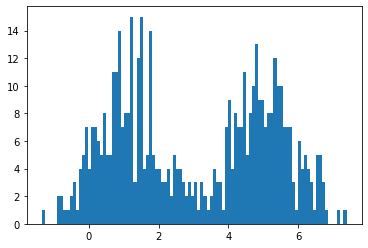

```python
plt.hist(X, bins=100)
```

调用自己编写的 EM 函数，进行参数估计。可以看到，EM估计的结果和设置的参数比较接近。

```python
m, v, w = EM(2, X, 0.005)
std = np.sqrt(v)
print(m)
print(std)
print(w)
```

```
[[1.08704939]
 [4.99361081]]
[[0.89187659]
 [0.9131791 ]]
[0.49976135 0.50023865]
```

调用 Sklearn 中自带的高斯混合模型参数估计，也得到了差不多的结果。

```python
gmm = mixture.GaussianMixture(n_components=2).fit(X)
print(gmm.means_)
print(gmm.covariances_)
print(gmm.weights_)
```

```
[[1.09287604]
 [5.00017769]]
[[[0.80432038]]

 [[0.82224985]]]
[0.50134734 0.49865266]
```

然后进行二维高斯混合模型的参数估计。代码实现上基本没有变化，只修改了参数的初值和长度。二维高斯分布的概率密度函数使用了 scipy 中的 multivariate_normal.pdf 函数。

```python
def step_E(X, mu, var, P):
    n_points, n_components = len(X), len(P)
    pdfs = np.zeros(((n_points, n_components)))
    for i in range(n_components):
        pdfs[:, i] = P[i] * multivariate_normal.pdf(X, mu[i], np.diag(var[i]))
    T = pdfs / pdfs.sum(axis=1).reshape(-1, 1)
    P = T.sum(axis=0) / n_points
    return T, P
```

```python
def step_M(X, T):
    n_components = T.shape[1]
    mu = np.zeros((n_components, 2))
    for i in range(n_components):
        mu[i] = np.average(X, axis=0, weights=T[:, i])
    n_components = T.shape[1]
    var = np.zeros((n_components, 2))
    for i in range(n_components):
        var[i] = np.average((X - mu[i]) ** 2, axis=0, weights=T[:, i])
    return mu, var
```

```python
def EM(n_components, X, eps):
    n_points = len(X)
    mu = [[0, 0], [2, 0], [0, 2]]
    var = [[1, 1], [1, 1], [1, 1]]
    P = [1 / n_components] * 3
    T = np.ones((n_points, n_components)) / n_components
    P = T.sum(axis=0) / n_points
    theta = np.array([P[0], P[1], P[2], mu[0][0], mu[0][1], mu[1][0], mu[1][1], var[0][0], var[0][1], var[1][0], var[1][1]])
    old_theta = np.zeros(theta.size)
    while np.linalg.norm(theta - old_theta) > eps:
        T, P = step_E(X, mu, var, P)
        mu, var = step_M(X, T)
        old_theta = theta
        theta = np.array([P[0], P[1], P[2], mu[0][0], mu[0][1], mu[1][0], mu[1][1], var[0][0], var[0][1], var[1][0], var[1][1]])
    return mu, var, P
```

还是使用 make_blobs 函数生成500个点的二维的高斯混合模型数据，均值和方差都是指定的。 画图看一下数据的样子。

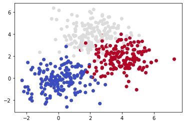

```python
X, y = make_blobs(n_samples=500, centers=[[0, 0], [2, 4], [4, 2]], n_features=2, cluster_std = [[1, 1], [1, 1], [1, 1]])
plt.scatter(X[:,0], X[:,1], c=y, cmap='coolwarm')
```

分别调用我们自己编写的 EM 算法和 sklearn 中自带的 GMM 参数估计进行参数估计。

```python
m, v, w = EM(3, X, 0.005)
std = np.sqrt(v)
print(m)
print(std)
print(w)
```

```
[[ 0.14205941 -0.11948984]
 [ 4.06013936  1.87591943]
 [ 2.12465158  3.88193502]]
[[1.09460363 0.97485306]
 [0.94161953 0.98110642]
 [1.02463142 1.01260904]]
[0.3421153  0.31080818 0.34707652]
```

可以看到，自编的 EM 算法和 sklearn 库中的参数估计也达到了基本差不多的效果。 我们还可以画图看一下sklearn把每个点分到了哪个高斯分布中。

```
[[ 4.03338403  1.90292239]
 [ 2.09615395  3.91701203]
 [ 0.14029946 -0.11498911]]
[[0.90623694 0.99092543]
 [1.01573605 0.98842185]
 [1.19092008 0.95892459]]
[0.32094204 0.33652192 0.34253603]
```

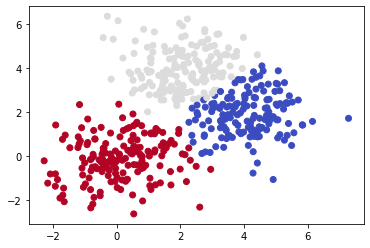

```python
gmm = mixture.GaussianMixture(n_components=3, covariance_type='diag').fit(X)
print(gmm.means_)
print(gmm.covariances_)
print(gmm.weights_)
labels = gmm.predict(X)
plt.scatter(X[:, 0], X[:, 1], c=labels, cmap='coolwarm');
```

## 总结

这次作业完成了 EM 算法对一维和二维高斯混合模型的参数估计任务，并和 Sklearn 中自带的高斯混合模型参数估计进行比较，达到了预期的效果。